# IS4487 Week 10 - Assignment

### Outline

Our Goals with this Project:

1. Import and review the data
2. Perform EDA and Clean Data
3. Fit a model
4. Test the accuracy of the model
5. Use the model to predict on a new dataset (without the target)

## Business Context AdviseInvest

You work on a small team of data analysts at AdviseInvest, a venture-backed startup. The Director of Sales at AdviseInvest has approached your team asking for help solving a staffing problem.

### The Company

The company's mission is to provide tools and support to help ordinary people gain control of their personal finances. The company leverages technology to provide affordable financial advice to a national client base.

Customers who reach AdviseInvest's website go through five steps:

- Open an account.
- Complete a customer profile form with basic information about their background and finances.
- Schedule a free phone conversation with a sales representative during a 1-hour window of time.
- Attend the free phone conversation.
- Buy a financial plan.
- There are three types of financial plans: Beginner, Intermediate, and Advanced. Each is sold at a different price, and there are varying degrees of personalization. After a customer purchases a financial plan, the customer is assigned a financial planner who helps determine the customer's goals and advises the customer on spending decisions.

### The Problem

Some customers are lost at each stage of the process. Steps 3 and 4 are particularly challenging because approximately 50% of those who schedule a phone conversation fail to pick up the call. This leads to inefficiencies from a staffing perspective.

AdviseInvest has 4 sales reps on staff during each particular 1-hour window. Each of the 4 reps is assigned 2 prospective customers per hour, which means that the company schedules a total of 8 phone calls per hour. The calls are outgoing: sales reps call customers who scheduled a phone conversation during that hour window.

Unfortunately, as noted above, many of the customers who scheduled a call do not answer. As a consequence, sales reps are often left underutilized. Moreover, they are underutilized unevenly. For example, it is possible that one sales rep will not do any sales calls during that hour, whereas another will be busy the entire hour with two calls. Sales reps have nothing to do when customers do not answer the scheduled phone call.

### AdviseInvest Data Dictionary

[output not shown]

### Load Libraries

Import the libraries you will need, such as:

- Pandas
- Sklearn
- Matplotlib

```python
import pandas as pd
import matplotlib.pyplot as plt
import seaborn as sns

from sklearn.model_selection import train_test_split
from sklearn.tree import DecisionTreeClassifier, plot_tree
from sklearn.metrics import accuracy_score, confusion_matrix

sns.set_theme(style='whitegrid')
```

## Step 1: Initial Data Understanding

### Do the following:

- Import data from the AdviseInvest historical dataset into a dataframe (in GitHub go to the DataSets folder and look for `adviseinvest_historical_data.csv`)
- Describe or profile the dataframe
- Look for any outliers, missing values, or duplicates

```python
url = 'https://raw.githubusercontent.com/Stan-Pugsley/is_4487_base/main/DataSets/adviseinvest_historical_data.csv'
df = pd.read_csv(url)

display(df.head())
df.info()
df.describe()
```

|  | customer_id | answered | income | female | age | job | num_dependents | rent | own_res | new_car | chk_acct | sav_acct | num_accts | mobile | product |
| --- | --- | --- | --- | --- | --- | --- | --- | --- | --- | --- | --- | --- | --- | --- | --- |
| 0 | 10098 | 0 | -65600 | 0 | 24 | 2 | 1 | 0 | 1 | 1.0 | 1 | 1 | 3 | 0 | 0 |
| 1 | 184 | 0 | 4330 | 0 | 24 | 2 | 2 | 1 | 0 | 0.0 | 1 | 3 | 1 | 0 | 0 |
| 2 | 194 | 0 | 4330 | 0 | 22 | 2 | 1 | 1 | 0 | 0.0 | 3 | 0 | 0 | 0 | 0 |
| 3 | 689 | 0 | 4330 | 0 | 24 | 2 | 2 | 1 | 0 | 0.0 | 1 | 3 | 1 | 0 | 0 |
| 4 | 811 | 0 | 4330 | 0 | 22 | 2 | 1 | 1 | 0 | 0.0 | 3 | 0 | 0 | 0 | 0 |

```
<class 'pandas.core.frame.DataFrame'>
RangeIndex: 29504 entries, 0 to 29503
Data columns (total 15 columns):
 #   Column          Non-Null Count  Dtype
---  ------          --------------  -----
 0   customer_id     29504 non-null  int64
 1   answered        29504 non-null  int64
 2   income          29504 non-null  int64
 3   female          29504 non-null  object
 4   age             29504 non-null  int64
 5   job             29504 non-null  int64
 6   num_dependents  29504 non-null  int64
 7   rent            29504 non-null  int64
 8   own_res         29504 non-null  int64
 9   new_car         29502 non-null  float64
 10  chk_acct        29504 non-null  int64
 11  sav_acct        29504 non-null  int64
 12  num_accts       29504 non-null  int64
 13  mobile          29504 non-null  int64
 14  product         29504 non-null  int64
dtypes: float64(1), int64(13), object(1)
memory usage: 3.4+ MB
```

|  | customer_id | answered | income | age | job | num_dependents | rent | own_res | new_car | chk_acct | sav_acct | num_accts | mobile | product |
| --- | --- | --- | --- | --- | --- | --- | --- | --- | --- | --- | --- | --- | --- | --- |
| count | 29504.000000 | 29504.000000 | 29504.000000 | 29504.000000 | 29504.000000 | 29504.000000 | 29504.000000 | 29504.000000 | 29502.000000 | 29504.000000 | 29504.000000 | 29504.000000 | 29504.000000 | 29504.000000 |
| mean | 14850.475563 | 0.546638 | 33766.893303 | 34.773454 | 1.915401 | 1.140998 | 0.210412 | 0.681128 | 0.240797 | 1.468547 | 0.956616 | 2.458345 | 0.091106 | 1.535792 |
| std | 8517.254310 | 0.497829 | 29379.202710 | 11.369865 | 0.658183 | 0.348025 | 0.407608 | 0.466047 | 0.427575 | 1.234727 | 1.483946 | 19.497380 | 0.287765 | 1.625916 |
| min | 99.000000 | 0.000000 | -65600.000000 | 19.000000 | 0.000000 | 1.000000 | 0.000000 | 0.000000 | 0.000000 | 0.000000 | 0.000000 | 0.000000 | 0.000000 | 0.000000 |
| 25% | 7474.750000 | 0.000000 | 13550.000000 | 26.000000 | 2.000000 | 1.000000 | 0.000000 | 0.000000 | 0.000000 | 0.000000 | 0.000000 | 2.000000 | 0.000000 | 0.000000 |
| 50% | 14850.500000 | 1.000000 | 23310.000000 | 32.000000 | 2.000000 | 1.000000 | 0.000000 | 1.000000 | 0.000000 | 1.000000 | 0.000000 | 2.000000 | 0.000000 | 1.000000 |
| 75% | 22226.250000 | 1.000000 | 41690.000000 | 40.000000 | 2.000000 | 1.000000 | 0.000000 | 1.000000 | 0.000000 | 3.000000 | 2.000000 | 3.000000 | 0.000000 | 3.000000 |
| max | 29602.000000 | 1.000000 | 159450.000000 | 132.000000 | 3.000000 | 2.000000 | 1.000000 | 1.000000 | 1.000000 | 3.000000 | 4.000000 | 3345.000000 | 1.000000 | 4.000000 |

```python
missing = df.isna().sum()
print('Missing values:')
print(missing[missing > 0])

print('\nExact duplicate rows:', df.duplicated().sum())

# How many times each row repeats if customer_id is ignored
copies = df.drop(columns='customer_id').value_counts(dropna=False)
print('Distinct rows without customer_id:', len(copies))
print(copies.value_counts())

print('\nLowest incomes:', df['income'].nsmallest(3).tolist())
print('Highest ages:', df['age'].nlargest(3).tolist())
print('num_accts values:', df['num_accts'].value_counts().sort_index().to_dict())
print('female values:', df['female'].value_counts().to_dict())

# product is recorded after the call
pd.crosstab(df['answered'], df['product'])
```

```
Missing values:
new_car    2
dtype: int64

Exact duplicate rows: 3
Distinct rows without customer_id: 469
count
64    453
63      8
1       8
Name: count, dtype: int64

Lowest incomes: [-65600, -15430, 2760]
Highest ages: [132, 74, 74]
num_accts values: {0: 1920, 1: 5184, 2: 10176, 3: 5246, 4: 6976, 8: 1, 3345: 1}
female values: {'0': 27903, '1': 1600, 'M': 1}
```

| product answered | 0 | 1 | 2 | 3 | 4 |
| --- | --- | --- | --- | --- | --- |
| 0 | 13376 | 0 | 0 | 0 | 0 |
| 1 | 0 | 2432 | 4672 | 2560 | 6464 |

### Reflection:

1.1. What stands out in the initial preview? Any columns or rows that seem unusual?

### ✍️ Your Response: 🔧

1.1. Some values aren't possible: two negative incomes (-$65,600 and -$15,430), an age of 132, and one customer with 3,345 accounts. Another has 8 accounts when everyone else has 0 to 4. `female` loaded as text because one row has "M" instead of 0 or 1, `new_car` is missing on 2 rows, and 3 rows are exact duplicates.

The data is also very repetitive. Without `customer_id`, only 469 of the 29,504 rows are different, and most customer profiles show up 64 times under different IDs. That means the training and test sets will share identical rows, so the test accuracy will probably look better than it should.

`product` stood out too. It's 0 for everyone who didn't answer and 1 to 4 for everyone who did, so it basically gives away the target.

# Step 2: Data Preparation

## 2.1: Data Cleanup

### Do the following:

- 2.1 Check for and remove any outliers
- 2.2 Consider fixing any missing data (should you delete the record or impute the value?)
- 2.3 remove any variables, like customer_id, that are not helpful in predicting the target variable (hint: are there any variables that are available only AFTER the customer has answered, and wouldn't be useful in predicting?)
- 2.4 Clean up the data and put it in a new dataframe named "df_clean"

```python
# Exact duplicates from step 1
df_clean = df.drop_duplicates()

# 2.1 Outliers: values that can't be real
df_clean = df_clean[
    (df_clean['income'] > 0) & (df_clean['age'] <= 100) & (df_clean['num_accts'] <= 4)
].copy()

# 2.2 Missing and bad data. 'M' is male, which the dictionary codes as 0.
df_clean['female'] = df_clean['female'].replace('M', '0')
df_clean = df_clean.dropna(subset=['new_car'])

# 2.3 customer_id is only a label, and product isn't known until after the call
df_clean = df_clean.drop(columns=['customer_id', 'product'])

# 2.4 Check the result
print('Rows before cleaning:', len(df))
print('Rows after cleaning:', len(df_clean))
df_clean.head()
```

```
Rows before cleaning: 29504
Rows after cleaning: 29494
```

|  | answered | income | female | age | job | num_dependents | rent | own_res | new_car | chk_acct | sav_acct | num_accts | mobile |
| --- | --- | --- | --- | --- | --- | --- | --- | --- | --- | --- | --- | --- | --- |
| 1 | 0 | 4330 | 0 | 24 | 2 | 2 | 1 | 0 | 0.0 | 1 | 3 | 1 | 0 |
| 2 | 0 | 4330 | 0 | 22 | 2 | 1 | 1 | 0 | 0.0 | 3 | 0 | 0 | 0 |
| 3 | 0 | 4330 | 0 | 24 | 2 | 2 | 1 | 0 | 0.0 | 1 | 3 | 1 | 0 |
| 4 | 0 | 4330 | 0 | 22 | 2 | 1 | 1 | 0 | 0.0 | 3 | 0 | 0 | 0 |
| 6 | 0 | 4330 | 0 | 22 | 2 | 1 | 1 | 0 | 0.0 | 3 | 0 | 0 | 0 |

### Reflection:

2.5 Explain the steps that you took to clean outliers and missing data. Why did you chose the approach that you used?

2.6 Which variables did you remove, and why?

### ✍️ Your Response: 🔧

2.5 Two negative incomes, an age of 132, and 3,345 accounts can't be real, and I also counted 8 accounts as an outlier since every other customer has 0 to 4. I deleted those 5 rows because there's no way to know the real values. I didn't use the IQR rule because income is skewed right, so it would have cut a lot of real high earners, and chart 3.2 shows they're less likely to answer.

`new_car` was blank on 2 rows, so I deleted those too. Guessing a yes/no value wouldn't add much, and 2 rows out of 29,504 won't change the model. The "M" in `female` was easy to fix because the dictionary codes male as 0. With the 3 duplicates removed as well, the data went from 29,504 rows to 29,494.

2.6 I removed `customer_id` because it's just an ID. I also removed `product` because it's recorded after the call, so it would give the model the answer and wouldn't exist yet for new customers.

## 2.2: Standardize variables

### Do the following:

- Change "answered" to a boolean (true/false) type
- Convert any variables that should be an integer into an integer

```python
df_clean['answered'] = df_clean['answered'].astype(bool)

# female was text because of the 'M', and new_car was a float because of the blanks
df_clean['female'] = df_clean['female'].astype(int)
df_clean['new_car'] = df_clean['new_car'].astype(int)

df_clean.dtypes
```

```
answered           bool
income            int64
female            int64
age               int64
job               int64
num_dependents    int64
rent              int64
own_res           int64
new_car           int64
chk_acct          int64
sav_acct          int64
num_accts         int64
mobile            int64
dtype: object
```

## 2.3 Convert variables

### Do the following:

- convert at least 3 variables to categorical where that data type is appropriate

```python
# These columns are codes for categories
for col in ['job', 'chk_acct', 'sav_acct']:
    df_clean[col] = df_clean[col].astype('category')

df_clean.dtypes
```

```
answered              bool
income               int64
female               int64
age                  int64
job               category
num_dependents       int64
rent                 int64
own_res              int64
new_car              int64
chk_acct          category
sav_acct          category
num_accts            int64
mobile               int64
dtype: object
```

# Step 3: Exploratory Data Analysis (EDA)

### Do the following:

- Explore the relationships between the target and independent variables
- Create at least five charts to show the relationships, using different chart types that are approriate to the analysis
- Ensure that all charts are clearly labeled and formatted

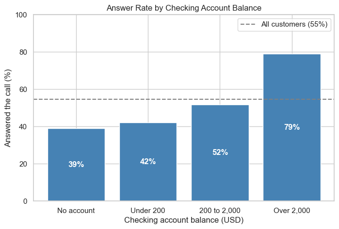

```python
# Chart 3.1: answer rate by checking account balance
checking_rate = df_clean.groupby('chk_acct', observed=True)['answered'].mean() * 100
overall_rate = df_clean['answered'].mean() * 100

plt.figure(figsize=(8, 5))
bars = plt.bar(['No account', 'Under 200', '200 to 2,000', 'Over 2,000'],
               checking_rate, color='steelblue')
plt.bar_label(bars, fmt='%.0f%%', label_type='center', color='white', fontweight='bold')
plt.axhline(overall_rate, color='gray', linestyle='--', label=f'All customers ({overall_rate:.0f}%)')
plt.title('Answer Rate by Checking Account Balance')
plt.xlabel('Checking account balance (USD)')
plt.ylabel('Answered the call (%)')
plt.ylim(0, 100)
plt.legend()
plt.show()
```

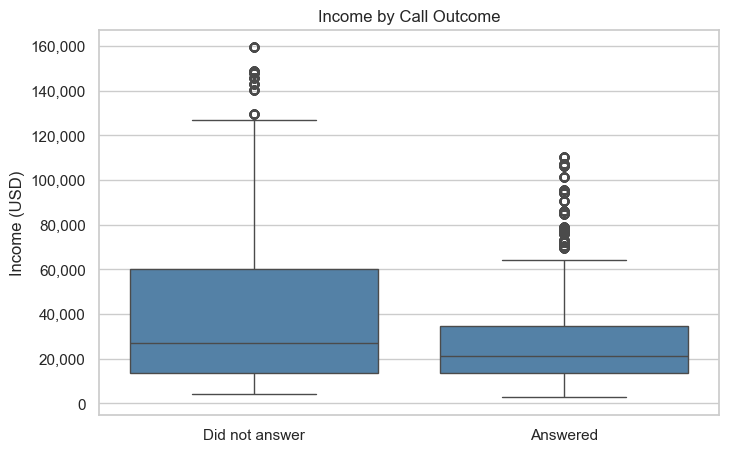

```python
# Chart 3.2: income of customers who did and didn't answer
plt.figure(figsize=(8, 5))
sns.boxplot(data=df_clean, x='answered', y='income', color='steelblue')
plt.xticks([0, 1], ['Did not answer', 'Answered'])
plt.gca().yaxis.set_major_formatter('{x:,.0f}')
plt.title('Income by Call Outcome')
plt.xlabel('')
plt.ylabel('Income (USD)')
plt.show()
```

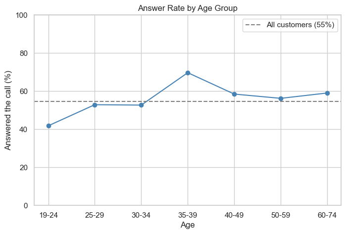

```python
# Chart 3.3: answer rate by age group
age_group = pd.cut(df_clean['age'], bins=[18, 24, 29, 34, 39, 49, 59, 74],
                   labels=['19-24', '25-29', '30-34', '35-39', '40-49', '50-59', '60-74'])
age_rate = df_clean.groupby(age_group, observed=True)['answered'].mean() * 100

plt.figure(figsize=(8, 5))
plt.plot(age_rate.index.astype(str), age_rate, marker='o', color='steelblue')
plt.axhline(overall_rate, color='gray', linestyle='--', label=f'All customers ({overall_rate:.0f}%)')
plt.title('Answer Rate by Age Group')
plt.xlabel('Age')
plt.ylabel('Answered the call (%)')
plt.ylim(0, 100)
plt.legend()
plt.show()
```

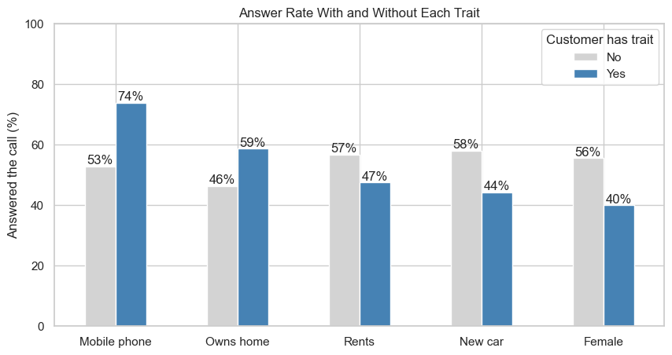

```python
# Chart 3.4: answer rate for the yes/no variables
yes_no_cols = ['mobile', 'own_res', 'rent', 'new_car', 'female']
trait_rates = pd.DataFrame({
    'No': [df_clean.loc[df_clean[col] == 0, 'answered'].mean() * 100 for col in yes_no_cols],
    'Yes': [df_clean.loc[df_clean[col] == 1, 'answered'].mean() * 100 for col in yes_no_cols],
}, index=['Mobile phone', 'Owns home', 'Rents', 'New car', 'Female'])

ax = trait_rates.plot(kind='bar', figsize=(10, 5), rot=0, color=['lightgray', 'steelblue'])
for bar_group in ax.containers:
    ax.bar_label(bar_group, fmt='%.0f%%')
ax.set_title('Answer Rate With and Without Each Trait')
ax.set_xlabel('')
ax.set_ylabel('Answered the call (%)')
ax.set_ylim(0, 100)
ax.legend(title='Customer has trait')
plt.show()
```

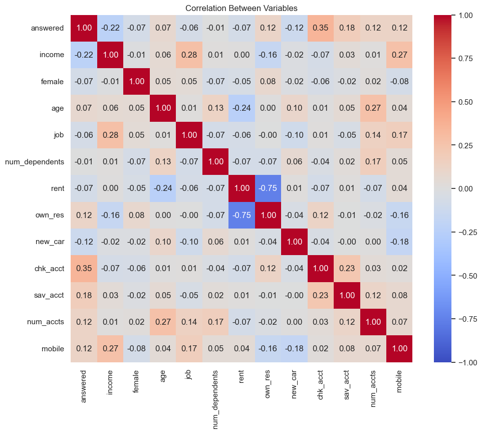

```python
# Chart 3.5: correlation between every variable (category codes treated as numbers)
corr = df_clean.astype(int).corr()

plt.figure(figsize=(11, 9))
sns.heatmap(corr, annot=True, fmt='.2f', cmap='coolwarm', center=0, vmin=-1, vmax=1)
plt.title('Correlation Between Variables')
plt.show()
```

### Reflection:

3.6. Which variables show the strongest relationship with the target variable?

3.7. Did you find any variables that have a weak relationship with the target variable? Should they be removed?

### ✍️ Your Response: 🔧

3.6. Checking account balance has the strongest relationship. Among customers with over $2,000 in checking, 79% answered, compared to 39% of customers with no checking account (correlation 0.35). Income is next (-0.22) and goes the other way, since customers who didn't answer earn more and no one over $111,000 answered. Savings (0.18), number of accounts (0.12), and having a mobile phone (74% vs. 53%) come after that. Age matters more than its 0.07 correlation suggests, because 19 to 24 year olds answered 42% of the time and 35 to 39 year olds answered 70%.

3.7. `num_dependents` barely relates to answering (-0.01), so I removed it. `job` is also weak (-0.06), but I kept it since the tree will ignore it if it doesn't help.

`female` has a low correlation (-0.07) mostly because only about 5% of customers are women. The actual gap is large, with 40% of women answering vs. 56% of men. I removed it anyway because I don't think gender should decide who gets a sales call.

## Step 4: Modeling

Start with the baseline. If we use no model at all, how good is our chance of predicting someone leaving? Use a calculation to find the chances of someone leaving.

### Do the following:

4.1 Calculate the base probability of answering

```python
base_rate = df_clean['answered'].mean()

print(df_clean['answered'].value_counts())
print(f'\nBase probability of answering: {base_rate:.2%}')
```

```
answered
True     16123
False    13371
Name: count, dtype: int64

Base probability of answering: 54.67%
```

## 4.2: Split the training and testing datasets

### Do the following:

- split df_clean using train_test_split function

Notes:

- all remaining variables except answered should be in the x variable
- answered is in the y variable

```python
# Everything except the target. num_dependents and female were dropped in 3.7.
X = df_clean.drop(columns=['answered', 'num_dependents', 'female'])
y = df_clean['answered']

X_train, X_test, y_train, y_test = train_test_split(X, y, test_size=0.2, random_state=42)

print('Training rows:', len(X_train))
print('Testing rows:', len(X_test))
```

```
Training rows: 23595
Testing rows: 5899
```

## 4.3: Create a Decision Tree

### Do the following:

- Create a tree
- Display (visualize) the tree

Notes:

- Use all available attributes (except those that were eliminated in step 3)
- It is recommended to use the type "entropy" and a max_depth of 4

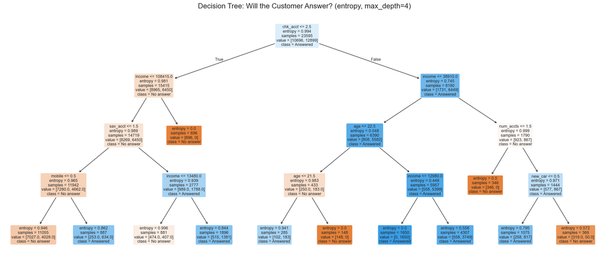

```python
tree_model = DecisionTreeClassifier(criterion='entropy', max_depth=4, random_state=42)
tree_model.fit(X_train, y_train)

plt.figure(figsize=(24, 10))
plot_tree(tree_model, feature_names=list(X.columns), class_names=['No answer', 'Answered'],
          filled=True, rounded=True, fontsize=9)
plt.title('Decision Tree: Will the Customer Answer? (entropy, max_depth=4)', fontsize=16)
plt.show()
```

## 4.4: Calculate the accuracy

This should be better than the base probability, or you have failed in your objective

### Do the following:

- Calculate the probability for your tree

```python
y_pred = tree_model.predict(X_test)
tree_accuracy = accuracy_score(y_test, y_pred)

print(f'Tree accuracy: {tree_accuracy:.2%}')
print(f'Base probability: {base_rate:.2%}')
print(f'Difference: {(tree_accuracy - base_rate) * 100:.1f} percentage points')
```

```
Tree accuracy: 74.42%
Base probability: 54.67%
Difference: 19.8 percentage points
```

### Reflection:

1. What is the difference between the probability from the model compared to the base probability?
2. Is this difference a significant amount for the business?

### ✍️ Your Response: 🔧

1. The tree is 74.4% accurate compared to the 54.7% base probability, so it's 19.8 percentage points better than assuming everyone answers.
2. Yes. Being right about 3 out of 4 times instead of about half the time would make scheduling reps a lot easier. Accuracy doesn't show what the mistakes cost, though. Missing a customer who would have answered loses $75, while a wasted call costs $25, so the profit numbers in step 5 matter more.

### 4.5: Confusion Matrix

### Do the following

- Create a confusion matrix

This will show false positives, true positives, etc.

```python
cm = confusion_matrix(y_test, y_pred)

pd.DataFrame(cm, index=['Actual: no answer', 'Actual: answered'],
             columns=['Predicted: no answer', 'Predicted: answered'])
```

|  | Predicted: no answer | Predicted: answered |
| --- | --- | --- |
| Actual: no answer | 2249 | 426 |
| Actual: answered | 1083 | 2141 |

Create a more visual, interpretable version of the matrix (hint - try using Seaborn Heatmap)

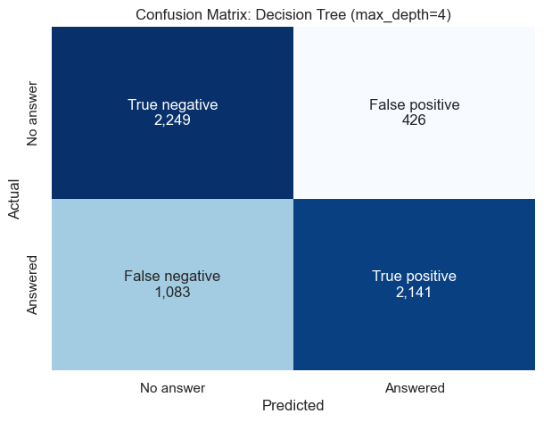

```python
labels = [[f'True negative\n{cm[0, 0]:,}', f'False positive\n{cm[0, 1]:,}'],
          [f'False negative\n{cm[1, 0]:,}', f'True positive\n{cm[1, 1]:,}']]

plt.figure(figsize=(7, 5))
sns.heatmap(cm, annot=labels, fmt='', cmap='Blues', cbar=False, annot_kws={'fontsize': 12},
            xticklabels=['No answer', 'Answered'], yticklabels=['No answer', 'Answered'])
plt.title('Confusion Matrix: Decision Tree (max_depth=4)')
plt.xlabel('Predicted')
plt.ylabel('Actual')
plt.show()
```

# Step 5: Evaluate the Model

**Assumptions**

There are costs and benefits in this case. We will assume that customers purchase a product for 100 dollars. This was the average cost of AdviseInvest products, according to the Director of Sales. Also, as we learned in the interview, the agent time to make the sale is worth 25 dollars. Profit would therefore be $75 dollars for an answered call and a purchase. In sum:

**Benefit**: True positive. The customer is predicted to answer, does answer, and purchases a product for 100 dollars for a profit of 100 - 25 = 75.

**Cost**: False positive. The customer is predicted to answer, but does not answer, so there is a loss of 25. (We assume the agent cannot schedule another call at the last minute, or spends the entire time slot trying to make the call.)

When you create a calculation you can use:

- True answered * 75 -> These people purchased
- False answered * 25 -> You can't schedule another call

For this exercise, we propose that customers who are not predicted to answer will not be called, so there would be no benefits and no costs for them.

### Do the following:

Calculate the Profit Using the Model

```python
tn, fp, fn, tp = cm.ravel()
model_profit = tp * 75 - fp * 25

print('True positives (called and answered):', tp)
print('False positives (called, no answer):', fp)
print('Calls made:', tp + fp)
print(f'Profit using the model: ${model_profit:,}')
print(f'Profit per call: ${model_profit / (tp + fp):.2f}')
```

```
True positives (called and answered): 2141
False positives (called, no answer): 426
Calls made: 2567
Profit using the model: $149,925
Profit per call: $58.40
```

### 5.2 Compare to the Default Profit

### Do the following:

- Calculate the profit (revenue - costs) that would be expected if all customers are called

Notes:

- We can consider this a baseline case for profit since it does not require a model
- In other words, to calculate profit in this baseline scenario treat the customers who answer as true positives treat the customers who do not answer as false positives.

```python
answered_total = y_test.sum()
no_answer_total = len(y_test) - answered_total
default_profit = answered_total * 75 - no_answer_total * 25

print('Answered:', answered_total)
print('Did not answer:', no_answer_total)
print('Calls made:', len(y_test))
print(f'Profit calling everyone: ${default_profit:,}')
print(f'Profit per call: ${default_profit / len(y_test):.2f}')
print('\nModel profit minus calling everyone:', model_profit - default_profit)
```

```
Answered: 3224
Did not answer: 2675
Calls made: 5899
Profit calling everyone: $174,925
Profit per call: $29.65

Model profit minus calling everyone: -25000
```

### Reflection:

1. What is the difference in profit between calling all customers and calling customers that are recommended by the model?
2. Is this a significant amount for the business?

### ✍️ Your Response: 🔧

1. The model makes $25,000 less than calling everyone ($149,925 vs. $174,925). It avoids 2,249 unanswered calls, but it also skips 1,083 customers who would have answered, and each of those costs $75 while each wasted call only costs $25.
2. Yes, $25,000 is about 14% less profit. That comparison assumes the slots the model skips just go unused, though, and AdviseInvest only has 8 call slots an hour. Per call, the model makes $58.40 vs. $29.65 because 2,141 of its 2,567 calls get answered, so if rep time is the limit, the model is the better option.

## 5.3 Tune the Model

### Do the Following

- Create a new version of the tree with new parameters
- Calculate a new probability

Notes:

- Adjust the size or shape of the tree, then test the accuracy
- Keep changing these parameters until you end up with a tree with accuracy that is better than the initial model

```python
for depth in [4, 5, 6, 8, 10, None]:
    tree = DecisionTreeClassifier(criterion='entropy', max_depth=depth, random_state=42)
    tree.fit(X_train, y_train)
    accuracy = accuracy_score(y_test, tree.predict(X_test))
    print(f'max_depth {depth}: accuracy {accuracy:.2%}, {tree.get_n_leaves()} leaves')

# The unlimited tree gets 100% because every test row has an exact copy in the training
# data (see step 1). Deeper trees are mostly memorizing those copies, so I only went to depth 5.
tree_tuned = DecisionTreeClassifier(criterion='entropy', max_depth=5, random_state=42)
tree_tuned.fit(X_train, y_train)

y_pred_tuned = tree_tuned.predict(X_test)
tuned_accuracy = accuracy_score(y_test, y_pred_tuned)
cm_tuned = confusion_matrix(y_test, y_pred_tuned)
tuned_profit = cm_tuned[1, 1] * 75 - cm_tuned[0, 1] * 25

print(f'\nTuned tree accuracy: {tuned_accuracy:.2%} (first tree: {tree_accuracy:.2%})')
print(f'Tuned tree profit: ${tuned_profit:,} (first tree: ${model_profit:,})')
```

```
max_depth 4: accuracy 74.42%, 12 leaves
max_depth 5: accuracy 77.00%, 20 leaves
max_depth 6: accuracy 78.88%, 29 leaves
max_depth 8: accuracy 82.05%, 44 leaves
max_depth 10: accuracy 84.03%, 58 leaves
```

```
max_depth None: accuracy 100.00%, 126 leaves

Tuned tree accuracy: 77.00% (first tree: 74.42%)
Tuned tree profit: $157,525 (first tree: $149,925)
```

### 5.4 Apply the Model to New Customers

### Do the Following

- Import the "adviseinvest_new_customer_data.csv" file
- Copy and past the data cleanup steps from 2.1 and 2.2
- Using the tree model that you created in step 5.3, predict each customer for the target variable by feeding the new customer data into the model
- Predict the number of customers who will be yes/no for the target variable

```python
new_url = 'https://raw.githubusercontent.com/Stan-Pugsley/is_4487_base/main/DataSets/adviseinvest_new_customer_data.csv'
new_customers = pd.read_csv(new_url)

# Same cleanup as 2.1 and 2.2. This file has no answered or product column, and
# customer_id stays so each prediction can be matched to a customer.
new_clean = new_customers.drop_duplicates()
new_clean = new_clean[
    (new_clean['income'] > 0) & (new_clean['age'] <= 100) & (new_clean['num_accts'] <= 4)
].copy()
new_clean['female'] = new_clean['female'].replace('M', '0')
new_clean = new_clean.dropna(subset=['new_car'])
new_clean['female'] = new_clean['female'].astype(int)
new_clean['new_car'] = new_clean['new_car'].astype(int)

print('New customers before cleaning:', len(new_customers))
print('New customers after cleaning:', len(new_clean))

new_clean['predicted_answer'] = tree_tuned.predict(new_clean[X.columns])
print('\nPredicted to answer (True) or not (False):')
print(new_clean['predicted_answer'].value_counts())
```

```
New customers before cleaning: 1000
New customers after cleaning: 1000

Predicted to answer (True) or not (False):
predicted_answer
False    551
True     449
Name: count, dtype: int64
```

# Step 6: Conclusion

### Reflection:

6.1: Did we improve our profit using the model?

6.2: How could the model be utilized by the business?

### ✍️ Your Response: 🔧

6.1 No, not in total profit. Calling everyone makes $174,925 on the test set, compared to $149,925 for the first tree and $157,525 for the tuned tree. Tuning helped a little, but the model's real improvement is profit per call ($58.40 vs. $29.65), which matters more with only 8 call slots an hour. All of these profit numbers are probably a bit high too, because 2,432 customers answered but didn't buy anything (`product` = 1).

6.2 AdviseInvest could score customers when they schedule, then give each rep a mix of likely and unlikely answerers. That would fix the uneven workload the Director of Sales described, where one rep sits through two no-shows while another is busy all hour. The tuned tree predicts 449 of the 1,000 new customers will answer, which gives them something to plan around. Before using it, I'd lower the cutoff from 50% to 25%. A call earns $75 and only risks $25, so anyone with better than a 25% chance of answering is worth calling when a slot is open. I'd also test it on real calls first, because the repeated rows make the test accuracy look better than it really is.

## Submission Instructions

✅ Checklist:

- All code cells run without error
- All markdown responses are complete
- Submit on Canvas as instructed

```python
!jupyter nbconvert --to html "assignment_10_classification.ipynb"
```

```
[NbConvertApp] Converting notebook assignment_10_classification.ipynb to html
```

```
[NbConvertApp] Writing 368764 bytes to assignment_10_classification.html
```